# Lab 1 - Ryan Perez

# Task 1

### 1. Identify, and list here, what aesthetics are being used and which variables are being mapped to each aesthetic.

```
**Income is on the x-axis, life expectancy is on the y-axis, and it is colored by region, while the size of each point references population.**
```

```python
pip install openpyxl
```

### 2. Import q1data.csv dataset

```python
import pandas as pd
import numpy as np

#First 5 rows of data from dataset
df1 = pd.read_excel(r'C:\Users\ryanc\Desktop\GSB_544\Data\q1data.xlsx')
df1.head()
```

|  | income | life_exp | population | year | country | four_regions | six_regions | eight_regions | world_bank_region |
| --- | --- | --- | --- | --- | --- | --- | --- | --- | --- |
| 0 | 1910.0 | 61.0 | 29200000.0 | 2010 | Afghanistan | asia | south_asia | asia_west | South Asia |
| 1 | 11100.0 | 78.1 | 2950000.0 | 2010 | Albania | europe | europe_central_asia | europe_east | Europe & Central Asia |
| 2 | 11100.0 | 74.7 | 36000000.0 | 2010 | Algeria | africa | middle_east_north_africa | africa_north | Middle East & North Africa |
| 3 | 46900.0 | 81.9 | 84500.0 | 2010 | Andorra | europe | europe_central_asia | europe_west | Europe & Central Asia |
| 4 | 7680.0 | 60.8 | 23400000.0 | 2010 | Angola | africa | sub_saharan_africa | africa_sub_saharan | Sub-Saharan Africa |

```python
from plotnine import ggplot, options, scale_size_area, annotate, labs, theme, geom_text, geom_point, aes, stat_smooth, facet_wrap, element_rect, scale_x_log10, ylab, xlab, theme_bw, theme_light, scale_y_continuous, scale_x_continuous, scale_fill_manual, guides
from plotnine import *
filtered1 = df1.dropna(subset=["income","life_exp","population","four_regions"]) #Removing empty values
```

### 3. Recreating Plot from Task 1

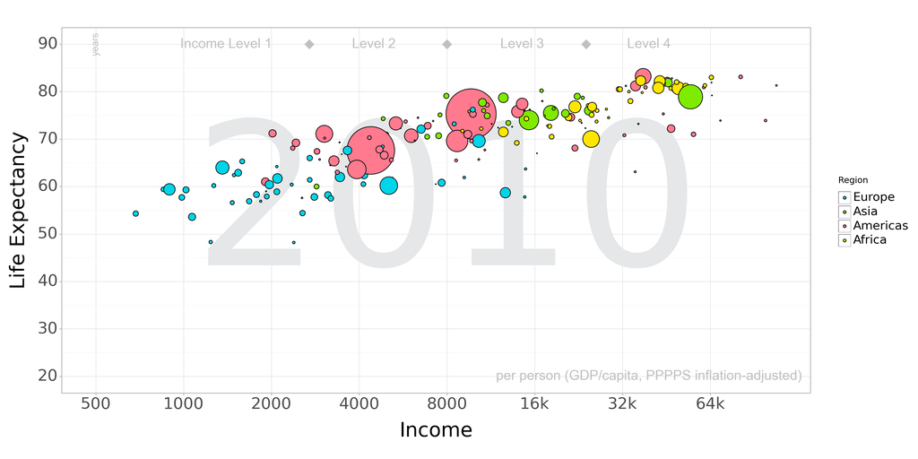

```python
#Part 3: Recreate the plot from Task 1
options.figure_size = (16,8)
region_colors = {
    'europe': '#FFE600',
    'asia': '#FF798F',
    'americas': '#7FEB00',
    'africa': '#00D5E9'
}
custom_color_labels = ["Europe", "Asia", "Americas", "Africa"]

plot1 = (ggplot(filtered1,
aes(
  x = "income",
  y = "life_exp",
  fill = "factor(four_regions)",
  size = "population"
))
+ annotate('text', x=8000, y=55, label='2010', color = '#E5E7E8', size=250, family="sans")
+ annotate('text', x=1400, y=90, label='Income Level 1', color = 'silver', size=17, family="Arial")
+ annotate('text', x=4500, y=90, label='Level 2', color = 'silver', size=17, family="Arial")
+ annotate('text', x=14500, y=90, label='Level 3', color = 'silver', size=17, family="Arial")
+ annotate('text', x=39500, y=90, label='Level 4', color = 'silver', size=17, family="Arial")
+ annotate('text', x=500, y=90, label='years', color = 'silver', size=12, family="Arial", angle = 90)
+ annotate(geom = "point", x = 2700, y = 90, shape = "D", color = 'silver', size = 4)
+ annotate(geom = "point", x = 8000, y = 90, shape = "D", color = 'silver', size = 4)
+ annotate(geom = "point", x = 24000, y = 90, shape = "D", color = 'silver', size = 4)
+ annotate('text', x=39500, y=20, label='per person (GDP/capita, PPPPS inflation-adjusted)', color = 'silver', size=17, family="Arial")
+ labs(x="Income", y="Life Expectancy", fill="Region")
+ scale_x_continuous(breaks=([500, 1000, 2000, 4000, 8000, 16000, 32000, 64000]),
                    labels = [500, 1000, 2000, 4000, 8000, "16k", "32k", "64k"],
                    trans = 'log2')
+ scale_y_continuous(limits = (20, 90),
                   breaks = range(20,100,10))
+ geom_point()
+ scale_size_area(max_size=35)
+ theme_light()
+ scale_fill_manual(values=region_colors,labels=custom_color_labels)
+ guides(size=False)
+ theme(axis_text_x=element_text(size=15))
+ theme(legend_text=element_text(size=15))
+ theme(axis_text_x=element_text(size=20), axis_text_y=element_text(size=20))
+ theme(axis_title_x=element_text(size=25), axis_title_y=element_text(size=25))
)
print(plot1)
```

## 4. What other geometries could you use here besides geom_point? Provide an actual plot of another geometry being used here and why it’s good or bad for visualizing these data.

While these three plots are great for comparing the 5-number-summary of income, life expectancy, and population of the regions, it is a lot more work to create three geometries in total, and makes it more difficult to compare all 4 aesthetics at the same time. One benefit is that you can compare regions to each other a little more easily for any of the three, as it is more difficult to compare the bubbles spread across the entire geometry. I immediately know the median of each region for the variables, where as I can only “eye-ball” it using the recreation.

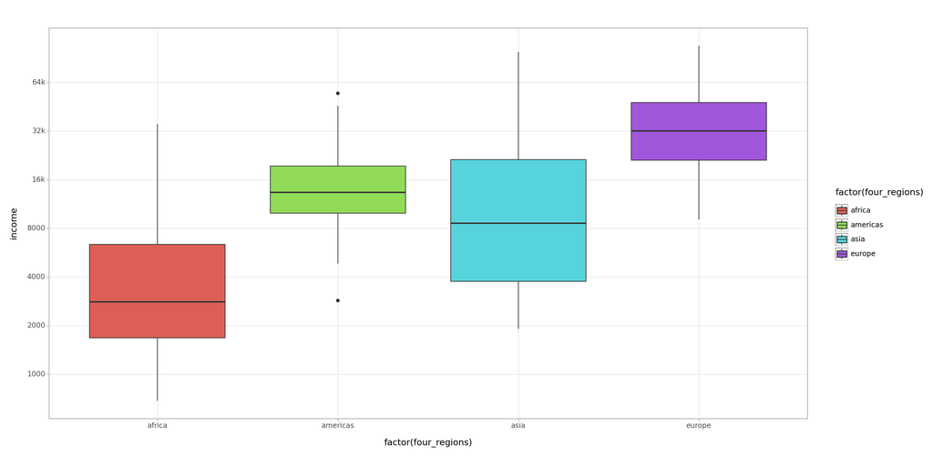

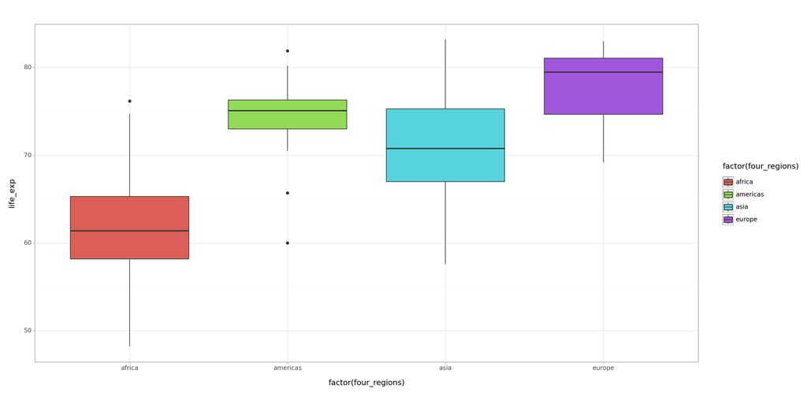

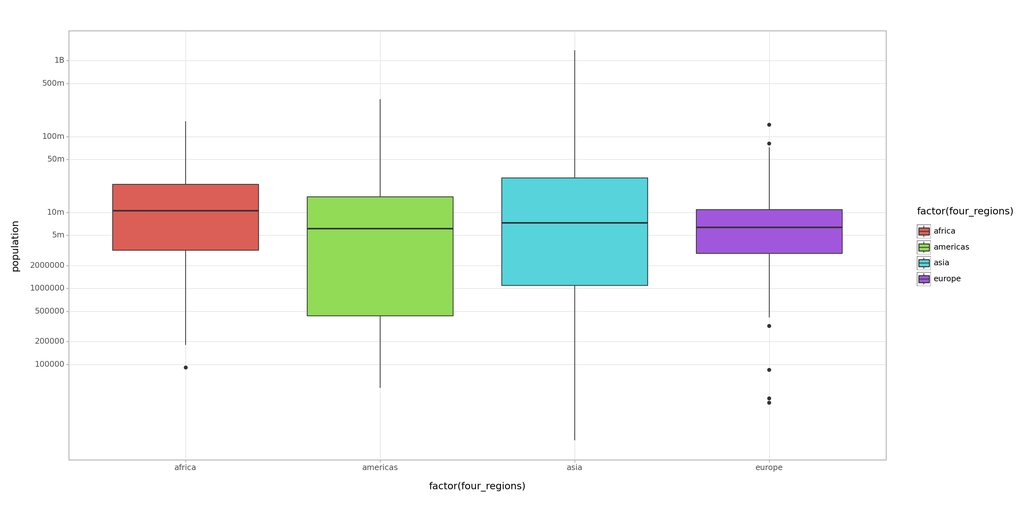

```python
plot1a =(ggplot(filtered1, aes(x = "factor(four_regions)", y = "income", fill = "factor(four_regions)"))
+ geom_boxplot()
+ theme_light()
+ scale_y_continuous(breaks=([500, 1000, 2000, 4000, 8000, 16000, 32000, 64000]),
                    labels = [500, 1000, 2000, 4000, 8000, "16k", "32k", "64k"],
                    trans = 'log2')
)
plot1b =(ggplot(filtered1, aes(x = "factor(four_regions)", y = "life_exp", fill = "factor(four_regions)"))
+ geom_boxplot()
+ theme_light()
)
plot1c =(ggplot(filtered1, aes(x = "factor(four_regions)", y = "population", fill = "factor(four_regions)"))
+ geom_boxplot()
+ scale_y_continuous(breaks=([100000, 200000, 500000, 1000000, 2000000, 5000000, 10000000, 50000000, 100000000, 500000000, 1000000000]),
                    labels = [100000, 200000, 500000, 1000000, 2000000, "5m", "10m", "50m", "100m", "500m", "1B"],
                    trans = 'log2')
+ theme_light()
)
print(plot1a)
print(plot1b)
print(plot1c)
```

# Task 2

### 1. Identify, and list here, what aesthetics are being used and which variables are being mapped to each aesthetic.

Exports is on the x-axis, with imports on the y-axis, while it is colored by region, and the size of dots is relative to the energy consumption

### 2. Import q2data.csv dataset

```python
#Importing dataset 2, first 5 rows below
df2 = pd.read_excel(r"C:\Users\ryanc\Desktop\GSB_544\Data\q2data.xlsx")
df2['energy'] = pd.to_numeric(df2['energy'], errors = 'coerce')
df2.head()
```

|  | imports | exports | energy | year | country | four_regions | six_regions | eight_regions | world_bank_region |
| --- | --- | --- | --- | --- | --- | --- | --- | --- | --- |
| 0 | NaN | NaN | NaN | 1997 | Afghanistan | asia | south_asia | asia_west | South Asia |
| 1 | 36.7 | 11.5 | 427.0 | 1997 | Albania | europe | europe_central_asia | europe_east | Europe & Central Asia |
| 2 | 22.5 | 22.6 | 825.0 | 1997 | Algeria | africa | middle_east_north_africa | africa_north | Middle East & North Africa |
| 3 | NaN | NaN | NaN | 1997 | American Samoa | NaN | NaN | NaN | NaN |
| 4 | NaN | NaN | 434.0 | 1997 | Angola | africa | sub_saharan_africa | africa_sub_saharan | Sub-Saharan Africa |

```python
#Removing empty cells
filtered2 = df2.dropna(subset=["exports","imports","energy","four_regions"])
```

### 3. Recreate the plot as best you can using plotnine

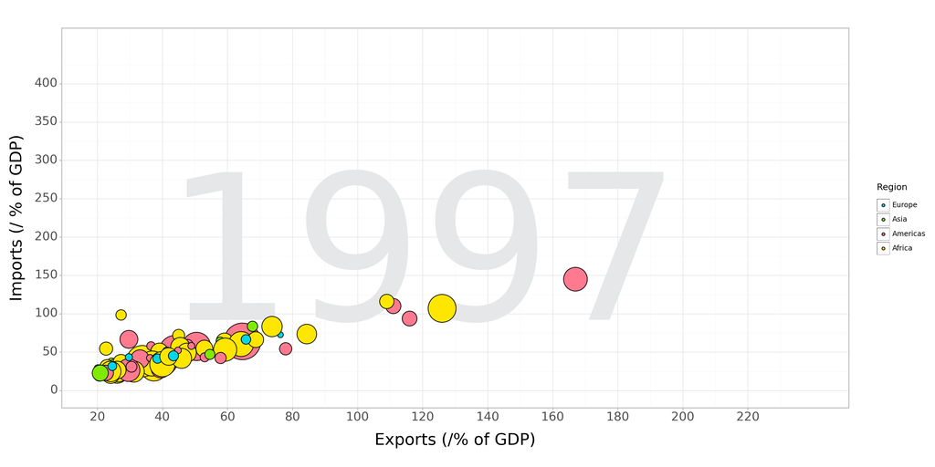

```python
#Part 3: Recreate the plot from Task 2
options.figure_size = (16,8)
region_colors = {
    'europe': '#FFE600',
    'asia': '#FF798F',
    'americas': '#7FEB00',
    'africa': '#00D5E9'
}
custom_color_labels = ["Europe", "Asia", "Americas", "Africa"]

plot2 = (ggplot(filtered2,
aes(
  x = "exports",
  y = "imports",
  fill = "factor(four_regions)",
  size = "energy"
))
+ labs(x="Exports (/% of GDP)", y="Imports (/ % of GDP)", fill="Region")
+ annotate('text', x=120, y=165, label='1997', color = '#E5E7E8', size=250, family="sans")
+ scale_x_continuous(limits = (20, 240),
                     breaks = range(20,240,20))
+ scale_y_continuous(limits = (0, 450),
                   breaks = range(0,450,50))
+ guides(size=False)
+ geom_point()
+ theme_light()
+ theme(axis_text_x=element_text(size=15), axis_text_y=element_text(size=15))
+ theme(axis_title_x=element_text(size=20), axis_title_y=element_text(size=20))
+ scale_size_area(max_size=25)
+ scale_fill_manual(values=region_colors,labels=custom_color_labels)
)
print(plot2)
```

## 4. What other geometries could you use here besides geom_point? Provide an actual plot of another geometry being used here and why it’s good or bad for visualizing these data.

The histograms do provide us with a better way to interpret the overall distribution of imports, exports, and energy for any one region. You can also compare the distirbution of any one of these variables between regions. Beyond this, the original recreation is doing a better job of showing all three variables simultaneously, as well as their influence on one another. Depending on the type of analysis you want to do, I could see either sets of geometries being helpful for different things.

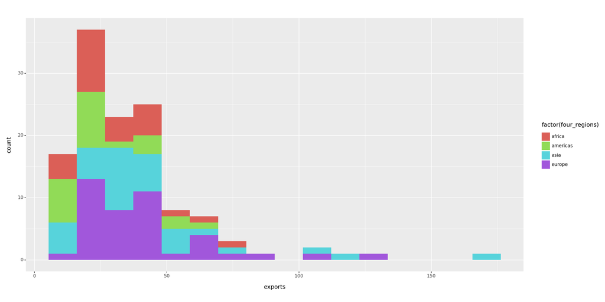

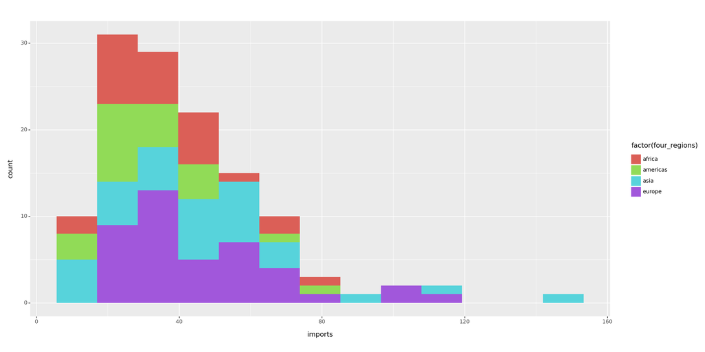

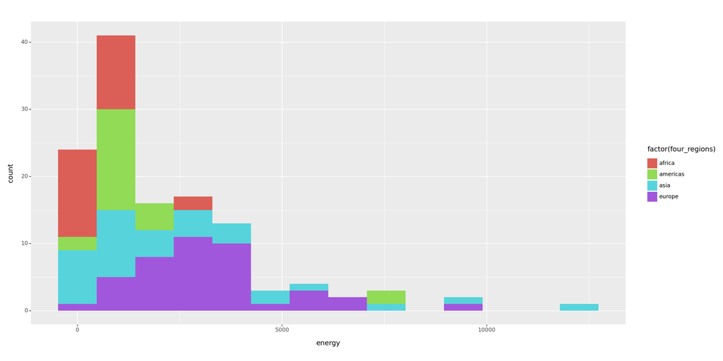

```python
plot2a =(ggplot(filtered2,
aes(
  x = "exports",
  fill = "factor(four_regions)"
))
+ geom_histogram()
)
plot2b =(ggplot(filtered2,
aes(
  x = "imports",
  fill = "factor(four_regions)"
))
+ geom_histogram()
)
plot2c =(ggplot(filtered2,
aes(
  x = "energy",
  fill = "factor(four_regions)"
))
+ geom_histogram()
)
print(plot2a)
print(plot2b)
print(plot2c)
```

# Task 3

### 1. Identify, and list here, what aesthetics are being used and which variables are being mapped to each aesthetic.

Internet users is represented on the x-axis, with GDP per capita on the y-axis, while it is colored by region, and the size of dots is relative to Income

### 2. Import q3data.csv dataset

```python
#Importing dataset 3, first 5 rows below
df3 = pd.read_excel(r"C:\Users\ryanc\Desktop\GSB_544\Data\q3data.xlsx")
df3.head()
```

|  | internet_users | gdp | income | year | country | four_regions | six_regions | eight_regions | world_bank_region |
| --- | --- | --- | --- | --- | --- | --- | --- | --- | --- |
| 0 | 0.00456 | 330.0 | 1190.0 | 2001 | Afghanistan | asia | south_asia | asia_west | South Asia |
| 1 | 0.39000 | 2570.0 | 6780.0 | 2001 | Albania | europe | europe_central_asia | europe_east | Europe & Central Asia |
| 2 | 1.59000 | 3770.0 | 9230.0 | 2001 | Algeria | africa | middle_east_north_africa | africa_north | Middle East & North Africa |
| 3 | NaN | 10500.0 | NaN | 2001 | American Samoa | NaN | NaN | NaN | NaN |
| 4 | 11.30000 | 42600.0 | 35600.0 | 2001 | Andorra | europe | europe_central_asia | europe_west | Europe & Central Asia |

```python
filtered3 = df3.dropna(subset=["internet_users","gdp","income","four_regions"])
```

### 3. Recreate the plot as best you can using plotnine

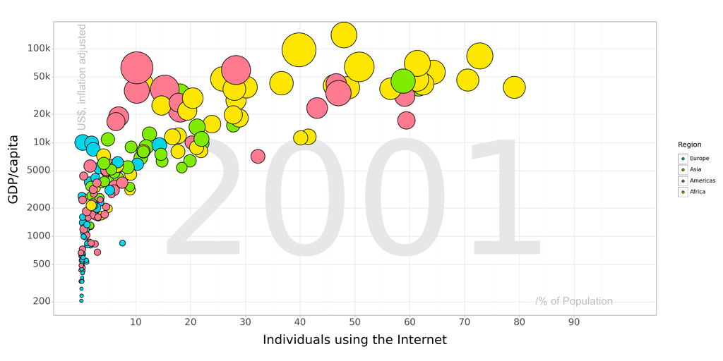

```python
region_colors = {
    'europe': '#FFE600',
    'asia': '#FF798F',
    'americas': '#7FEB00',
    'africa': '#00D5E9'
}
custom_color_labels = ["Europe", "Asia", "Americas", "Africa"]

plot2 = (ggplot(filtered3,
aes(
  x = "internet_users",
  y = "gdp",
  fill = "factor(four_regions)",
  size = "income"
))
+ annotate('text', x=50, y=1875, label='2001', color = '#E5E7E8', size=250, family="sans")
+ annotate('text', x=90, y=200, label='/% of Population', color = 'silver', size=17, family="Arial")
+ annotate('text', x=.2, y=50000, label='US$, inflation adjusted', color = 'silver', size=17, family="Arial", angle = 90)
+ labs(x="Individuals using the Internet", y="GDP/capita", fill="Region")
+ scale_y_continuous(breaks=([200, 500, 1000, 2000, 5000, 10000, 20000, 50000, 100000]),
                    labels = [200, 500, 1000, 2000, 5000, "10k", "20k", "50k", "100k"],
                    trans = 'log2')
+ scale_x_continuous(limits = (0, 100),
                     breaks = range(10,100,10))
+ guides(size=False)
+ geom_point()
+ theme_light()
+ theme(axis_text_x=element_text(size=15), axis_text_y=element_text(size=15))
+ theme(axis_title_x=element_text(size=20), axis_title_y=element_text(size=20))
+ scale_size_area(max_size=30)
+ scale_fill_manual(values=region_colors,labels=custom_color_labels)
)
print(plot2)
```

## 4. What other geometries could you use here besides geom_point? Provide an actual plot of another geometry being used here and why it’s good or bad for visualizing these data.

The density plots once again allow us to check the distribution of internet users, GDP, and income for any one region, as well as compare between the different regions.This may be a little more clunky when trying to compare everything at the same time, in which case the original recreation would be more helpful. As always, depends on the goal of analysis.

!!Issues with changing x-scale for these, I kept getting a warning that my breaks and labels didn’t match up. Not sure…

```
C:\Users\ryanc\anaconda3\Lib\site-packages\pandas\core\arraylike.py:402: RuntimeWarning: divide by zero encountered in log2
C:\Users\ryanc\anaconda3\Lib\site-packages\plotnine\layer.py:284: PlotnineWarning: stat_density : Removed 1 rows containing non-finite values.
```

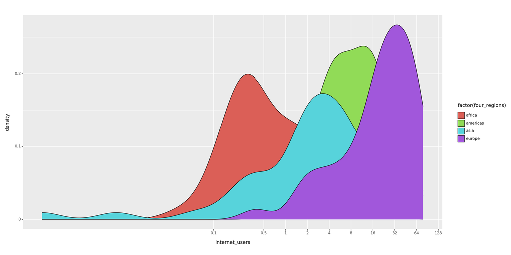

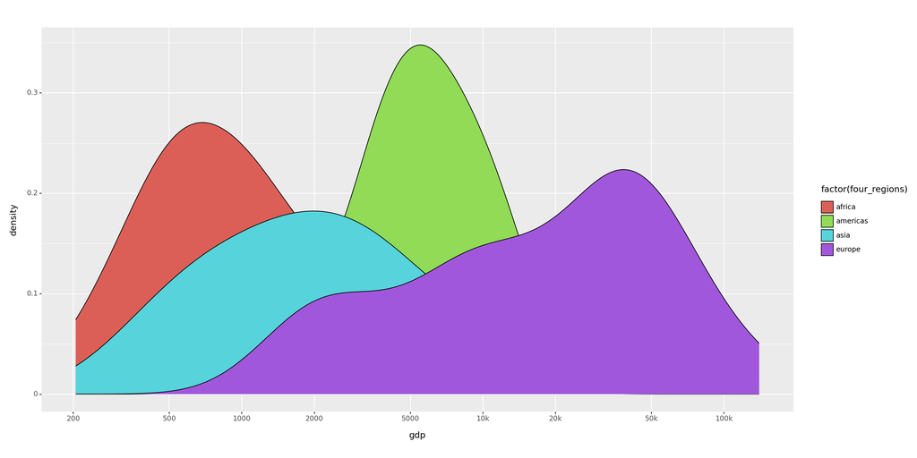

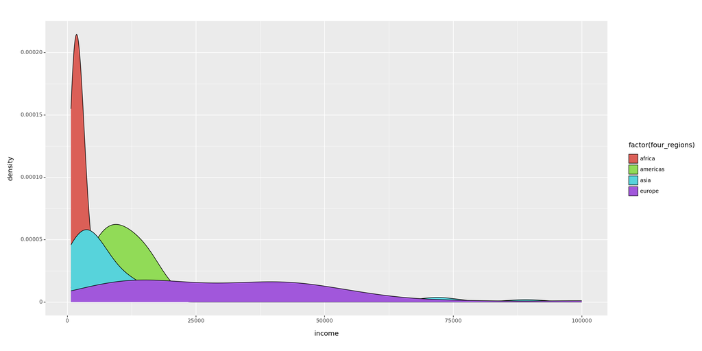

```python
plot3a = (ggplot(filtered3,
aes(
  x = "internet_users",
  fill = "factor(four_regions)"
))
+ scale_x_continuous(
              breaks=[0.1, 0.5, 1, 2, 4, 8, 16, 32, 64, 128],
              labels=[0.1, 0.5, 1, 2, 4, 8, 16, 32, 64, 128],
              trans='log2')
+ geom_density()
)
plot3b = (ggplot(filtered3,
aes(
  x = "gdp",
  fill = "factor(four_regions)"
))
+ scale_x_continuous(breaks=[200, 500, 1000, 2000, 5000, 10000, 20000, 50000, 100000],
                    labels = [200, 500, 1000, 2000, 5000, "10k", "20k", "50k", "100k"],
                    trans = 'log2')
+ geom_density()
)
plot3c = (ggplot(filtered3,
aes(
  x = "income",
  fill = "factor(four_regions)"
))
+ geom_density()
)
print(plot3a)
print(plot3b)
print(plot3c)
```